# Final_Project_ML

# Creating dummy variables of categorical values to find correlation.

```r
#creating dummy variables of gender and finding correlation with rating
dummy <-dummyVars("~ gender",data=datamovies, fullRank = T)
datamovies['gender_DV'] <- data.frame(predict(dummy, newdata = datamovies))

cor(datamovies$rating,datamovies$gender_DV)
```

```
## [1] -0.005215621
```

```r
#timesincereleased is null so remove it
datamovies <- datamovies[c(-32,-7)]


# Converting timestamp from char to Date to find cor with rating
datamovies$timestamp <- as.POSIXct(datamovies$timestamp, format="%m/%d/%Y")
Timstamp_Numeric <- as.numeric(datamovies$timestamp)

cor(Timstamp_Numeric, datamovies$rating)
```

```
## [1] -0.1539925
```

```r
# Correlation of age with rating
cor(datamovies$rating,datamovies$age)
```

```
## [1] 0.05449031
```

```r
# Correlation of runtime with rating
cor(datamovies$rating,datamovies$Runtime)
```

```
## [1] 0.1295327
```

```r
#Correlation of rating with dayReviewed
cor(datamovies$rating,datamovies$dayReviewed)
```

```
## [1] 0.02461948
```

```r
#Correlation of rating with monthReviewed
cor(datamovies$rating,datamovies$monthReviewed)
```

```
## [1] -0.09130459
```

```r
# Normalizing the values inorder to get correlation
#correlation of rating with Imdb rating
ratingnorm <- scale(datamovies$rating)
summary(ratingnorm)
```

```
##        V1
##  Min.   :-2.2294
##  1st Qu.:-0.4475
##  Median : 0.4435
##  Mean   : 0.0000
##  3rd Qu.: 0.4435
##  Max.   : 1.3344
```

```r
Imdbratingnorm <- scale(datamovies$imdbRating)
summary(Imdbratingnorm)
```

```
##        V1
##  Min.   :-1.162790
##  1st Qu.:-0.565821
##  Median :-0.360613
##  Mean   : 0.000000
##  3rd Qu.:-0.006163
##  Max.   : 4.191274
```

```r
datamovies$rating <- ratingnorm
datamovies$imdbRating <- Imdbratingnorm


cor(ratingnorm,Imdbratingnorm)
```

```
##            [,1]
## [1,] -0.1225958
```

```r
# Converting occupation to dummy and finding cor with rating
#datamovies['occupation_DV'] <- NA

dummy <-dummyVars("~ occupation",data=datamovies, fullRank = T) #creating dummy variables from factors in movies set.
moviedummy <- data.frame(predict(dummy, newdata = datamovies))

anova <- aov(datamovies$rating ~ moviedummy$occupationartist + moviedummy$occupationdoctor + moviedummy$occupationeducator + moviedummy$occupationengineer + moviedummy$occupationentertainment + moviedummy$occupationexecutive + moviedummy$occupationhealthcare +moviedummy$occupationlawyer + moviedummy$occupationlibrarian +moviedummy$occupationmarketing + moviedummy$occupationnone +moviedummy$occupationother +moviedummy$occupationprogrammer +moviedummy$occupationretired +moviedummy$occupationsalesman +moviedummy$occupationscientist +moviedummy$occupationstudent +moviedummy$occupationtechnician +moviedummy$occupationwriter)

anova$coefficients
```

```
##                        (Intercept)        moviedummy$occupationartist
##                        0.076756775                        0.017961730
##        moviedummy$occupationdoctor      moviedummy$occupationeducator
##                        0.057224077                        0.063361657
##      moviedummy$occupationengineer moviedummy$occupationentertainment
##                       -0.066370291                       -0.156166585
##     moviedummy$occupationexecutive    moviedummy$occupationhealthcare
##                       -0.253803725                       -0.638613205
##        moviedummy$occupationlawyer     moviedummy$occupationlibrarian
##                        0.086211665                       -0.038419205
##     moviedummy$occupationmarketing          moviedummy$occupationnone
##                       -0.119671144                        0.175325162
##         moviedummy$occupationother    moviedummy$occupationprogrammer
##                       -0.044533415                       -0.055179551
##       moviedummy$occupationretired      moviedummy$occupationsalesman
##                       -0.136771609                       -0.042112082
##     moviedummy$occupationscientist       moviedummy$occupationstudent
##                       -0.007089158                       -0.093018466
##    moviedummy$occupationtechnician        moviedummy$occupationwriter
##                       -0.078238232                       -0.205999930
```

```r
# We see that healthcare professionals have a negative correlation with ratings.
```

# Data preparation for clustering

```r
library(factoextra)
library(klaR)
library(MASS)
library(fpc)
library(caret)
library(cluster)


datamovies$occupation <- as.factor(datamovies$occupation)
datamovies$view <- as.factor(datamovies$view)


# Removing  columns such as movie title which is not needed for our analysis.
df <- datamovies[,c(-9,-10,-11,-36,-37,-34,-5,-8,-33,-35,-36,-7)]
```

# Principal Component Analysis (PCA)

# I have normalized the data for performing Principal component analysis which is an important step before implementing PCA which requires the data has to be a single scale before performing PCA.

```r
#Normalization of data for PCA
normalize <- function(x)
{
return((x - min(x)) / (max(x) - min(x)))
}

moviesnorm <- as.data.frame(lapply(df[-24], normalize))
dfdata <- preProcess(moviesnorm,method = c("BoxCox","center","scale","pca"))
d <- predict(dfdata,df)
```

# I have used the elbow method to determine the value of K.

# So where the graph becomes almost flat I have used that as the value of K. As we can see here I have taken K = 4 seeing the graph below.

```r
#Elbow Method for finding the optimal number of clusters
set.seed(123)
# Compute and plot wss for k = 2 to k = 15.
k.max <- 15
data <- moviesnorm
value_k <- sapply(1:k.max,
              function(k){kmeans(data, k, nstart=50,iter.max = 15 )$tot.withinss})
value_k
```

```
##  [1] 172319.79 150374.41 133964.70 125552.18 119965.92 114529.70 110228.20
##  [8] 106720.46 103303.90 100340.19  97917.46  95870.70  94005.98  92127.74
## [15]  90223.64
```

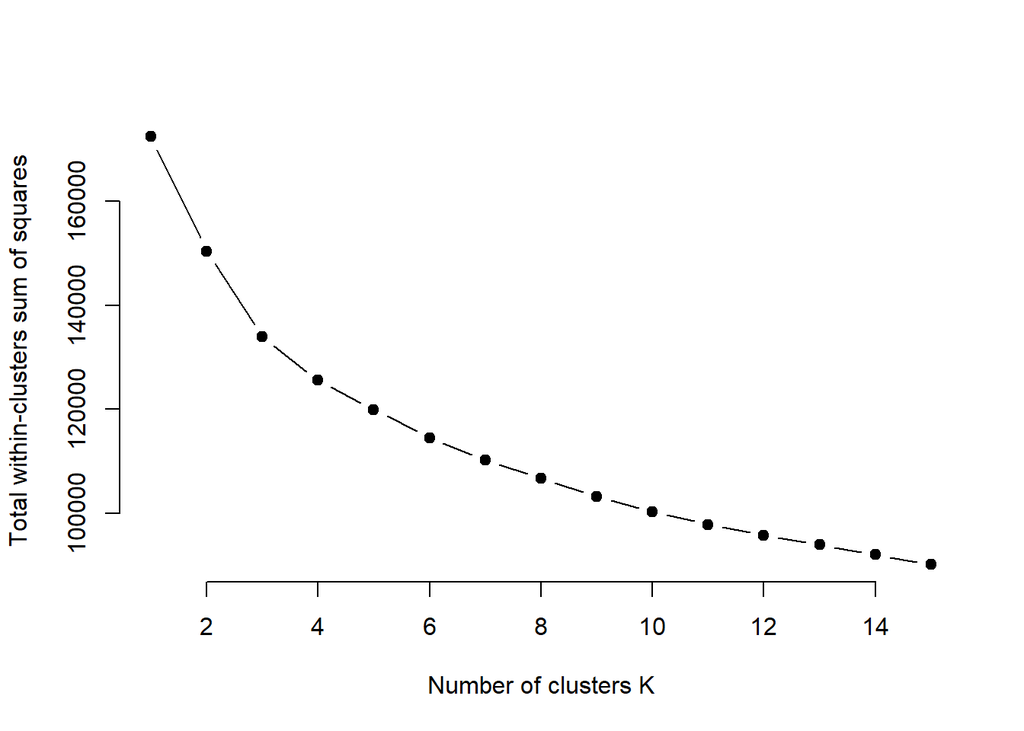

```r
plot(1:k.max, value_k,
     type="b", pch = 19, frame = FALSE,
     xlab="Number of clusters K",
     ylab="Total within-clusters sum of squares")
```

# Hierarchical clustering and plotting dendogram for visualization and also the cutting of the dendogram using cutree function.

# I have done hierarchical clustering because I want to group users into segments or groups inorder to be able to recommend movies for a customer in a particular group.

# I have used Eucledian distance for calculating the distance as it is best suited with hierarchical clustering.

# I have also used complete linkage hierarchical clustering as it is also called the farthest neighbor which means the the distance between the clusters is the distance between the two most distant objects.

# This helps in creation of proper segmentation and clustering for building a movie recommendation system.

```r
# Dissimilarity matrix and hierarchical clustering

subset <- d[1:1000,]
p <- get_dist(subset,method = "euclidean")
```

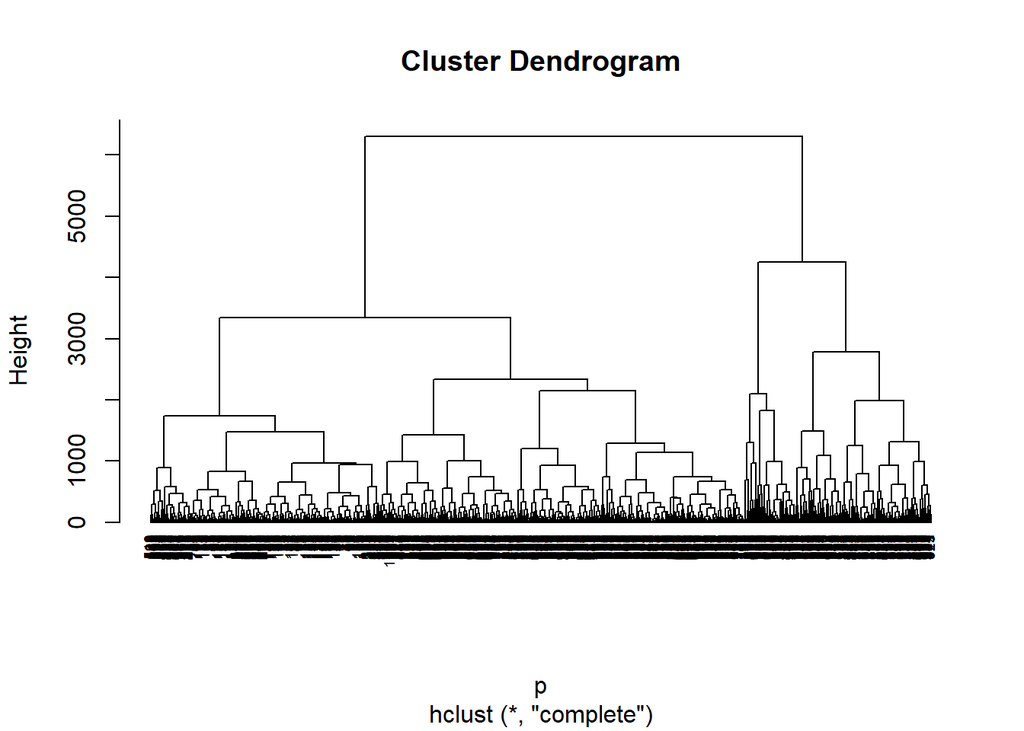

```r
# Hierarchical clustering using Complete Linkage
hc1 <- hclust(p, method = "complete" )

# Plot the obtained dendrogram
plot(hc1, cex = 0.6, hang = -1)
```

```r
groups <- cutree(hc1, k=4)


subset$cluster <- groups
```